# Model the Total Cost of Ownership for electric transport vehicles

Jakolien van der Meer

HZ University of Applied Sciences

### Run Excell spreadsheet Topsector Logistiek

To be able to calculate the TCO value for several input values, we rewrite values in the excel sheet and then import the results in this notebook.

Ask the user for input values and insert in excel sheet.

```
Voertuigtype: Kleine bakwagen (12t)
Koelmachine (J/N): j
Verwacht jaarkilometrage: 30000
Grijze/groene elektriciteit: grijs
Capaciteit vrachtwagenbatterij:
Vermogen eigen oplaadsysteem:
```

Read results from workbook and put in a list, then show in a table.

|  | EV | Diesel |
| --- | --- | --- |
| a: Totale vaste voertuigkosten per jaar | 9708.6589 | 4669.8770 |
| b: Totale variabele voertuigkosten per jaar | 26209.1183 | 16486.4099 |
| c: Totale kosten oplaadsysteem per jaar | 447.0000 | 0.0000 |
| d: Totale chauffeurskosten per jaar | 73944.0000 | 73944.0000 |
| e: Totale overhead per jaar | 17649.4044 | 15216.0459 |
| Totale kosten per km: (a+b+c+d+e)/ kms per jaar | 4.2653 | 3.6772 |
| Totale kosten per uur: (a+b+c+d+e)/ uren per jaar | 49.2147 | 42.4294 |

Plot the tco components for EV and diesel.

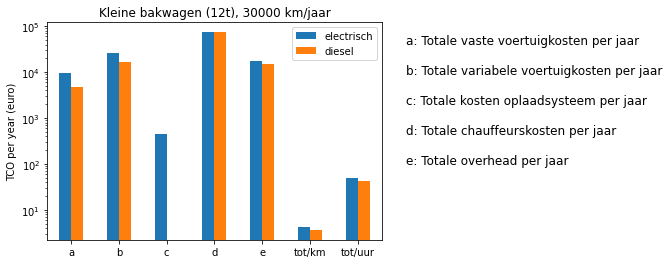

Plot as a stacked diagram.

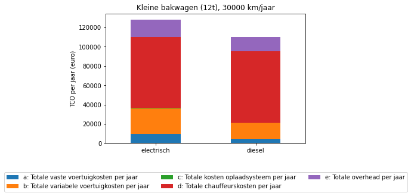

make a pie plot.

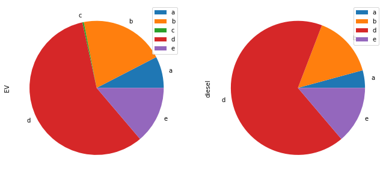

Calculate and plot the total costs per year vs the number of km/year.

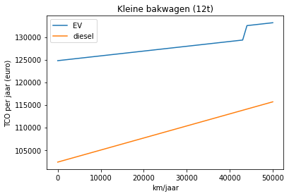

Do the same for co2.

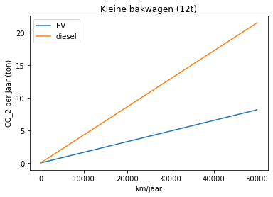

Show all the results in a table.

|  | EV thuis opladen | EV optimale mix | Diesel |
| --- | --- | --- | --- |
| RESULTATEN |  |  |  |
| Scenario | Uitsluitend thuis opladen | Optimale mix | Diesel |
| Scenario technisch mogelijk/niet mogelijk | Scenario valid | Scenario valid | Scenario valid |
| Voertuigtype | Kleine bakwagen (12t) 120 kWh | Kleine bakwagen (12t) 120 kWh | Kleine bakwagen (12t) |
| Eigen oplaadsysteem | AC20 | AC20 | nvt |
| Openbaar oplaadsysteem | AC20 | AC10 | nvt |
| Percentage eigen oplaadsysteem | 1 | 1 | nvt |
| Percentage extern (openbaar) oplaadsysteem | 0 | 0 | nvt |
| Totale kosten per jaar | 133171.7435 | 133171.7435 | 115655.3822 |
| Totale kosten per km | 2.6634 | 2.6634 | 2.3131 |
| Totale kosten per uur | 51.2199 | 51.2199 | 44.4828 |
| Emissies (totaal per jaar voor het geselecteerde voertuig, WtW) | 1 | 2 | 3 |
| CO2 emissies (ton per jaar) | 8.15216 | 8.15216 | 21.4907 |
| PM_totaal (kg per jaar) | 4.06034 | 4.06034 | 4.33345 |
| NOx_ (kg per jaar) | 10.0856 | 10.0856 | 43.104 |
| ONDERBOUWING KOSTENBEREKENING |  |  |  |
| Vaste kosten per jaar |  |  |  |
| Wegenbelasting (dieselvoertuigen) | 0 | 0 | 312 |
| Eurovignet | 750 | 750 | 750 |
| Rente | 4259.6114 | 4259.6114 | 1538.877 |
| Verzekering | 5536 | 5536 | 2000 |
| Voertuigheffing | 0 | 0 | 0 |
| Diverse overige voertuigkosten | 69 | 69 | 69 |
| a: Totale vaste voertuigkosten per jaar | 10614.6114 | 10614.6114 | 4669.877 |
| Fixed transport costs | 10989.6114 | 10989.6114 | 5044.877 |
| Variabele kosten per jaar |  |  |  |
| Afschrijving voertuig | 19002.7756 | 19002.7756 | 6865.1646 |
| Brandstofverbruik voertuig | 0 | 0 | 6143.6636 |
| Brandstofverbruik koeling | 0 | 0 | 1817.9086 |
| Elektriciteitsverbruik | 2471.7382 | 2471.7382 | 0 |
| Banden | 975 | 975 | 975 |
| Onderhoud | 1130.8 | 1130.8 | 2570 |
| Reparatie | 5000 | 5000 | 1500 |
| Reparatie/onderhoud koelunit | 842.302 | 842.302 | 842.302 |
| Verschil Tolheffing (km-tarief) | 0 | 0 | 0 |
| CO2 prijs | 0 | 0 | 0 |
| Specifieke vervoerskosten | 375 | 375 | 375 |
| b: Totale variabele voertuigkosten per jaar | 29797.6157 | 29797.6157 | 21089.0387 |
| Repair, maintenance & tires | 2105.8 | 2105.8 | 3545 |
| Kosten oplaadsysteem per jaar |  |  |  |
| Aankoop en installatie | 282 | 282 | 0 |
| Operationele kosten | 165 | 165 | 0 |
| c: Totale kosten oplaadsysteem per jaar | 447 | 447 | 0 |
| Totale voertuig en oplaadsysteemkosten per jaar (a+b+c) | 40859.2271 | 40859.2271 | 25758.9157 |
| Totale voertuig en oplaadsysteemkosten per km: (a+b+c)/kms per jaar | 0.8172 | 0.8172 | 0.5152 |
| Totale voertuig en oplaadsysteemkosten per uur (a+b+c)/uren per jaar | 15.7151 | 15.7151 | 9.9073 |
| Chauffeurskosten |  |  |  |
| Uurloon incl. sociale lasten | 70538 | 70538 | 70538 |
| Verblijfkostenvergoeding | 2210 | 2210 | 2210 |
| Overige kosten | 1196 | 1196 | 1196 |
| d: Totale chauffeurskosten per jaar | 73944 | 73944 | 73944 |
| Totale directe kosten per jaar (a+b+c+d) | 114803.2271 | 114803.2271 | 99702.9157 |
| Totale directe kosten per km: (a+b+c+d)/kms per jaar | 2.2961 | 2.2961 | 1.9941 |
| Totale directe kosten per uur (a+b+c+d)/uren per jaar | 44.1551 | 44.1551 | 38.3473 |
| Algemene kosten (overhead) |  |  |  |
| Loon incl. sociale lasten | 9643.4711 | 9643.4711 | 8375.0449 |
| Huisvesting | 2984.8839 | 2984.8839 | 2592.2758 |
| Overig | 5740.1614 | 5740.1614 | 4985.1458 |
| e: Totale overhead per jaar | 18368.5163 | 18368.5163 | 15952.4665 |
| Totale kosten per jaar (a+b+c+d+e) | 133171.7435 | 133171.7435 | 115655.3822 |
| Totale kosten per km: (a+b+c+d+e)/ kms per jaar | 2.6634 | 2.6634 | 2.3131 |

### Include a time axis to the model

To come up with a smart TCO model that includes the evaluation of the cost components in time, we need to define a time scale first.

```
[2021, 2022, 2023, 2024, 2025, 2026, 2027, 2028, 2029, 2030, 2031, 2032, 2033, 2034, 2035]
```

We predict a certain change in vehicle prices for both diesel and electric vehicles.

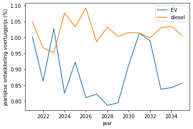

We can plot the price evolution for a certain type of vehicle, with a band denoting the standard deviation.

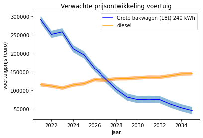

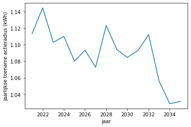

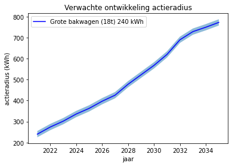

Now we are able to change the input parameters in the excel sheet over the years, and read how the tco values for a certain type of vehicle will evolve accordingly.

Again, we can plot the curves for this type of electric and diesel truck.

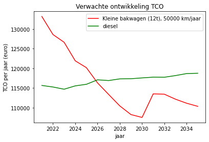

Obtain the year of intersection, where 'tco diesel' = 'tco electric'

```
year that "TCO EV" = "TCO diesel" =  5
```

Put the results in a histogram.

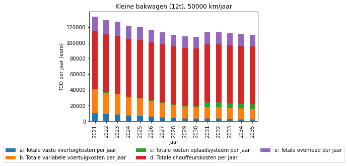

Predict the evolution of the residual value in time

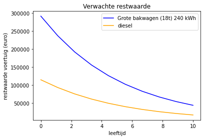

### Find best time to replace diesel vehicle by BEV

- strategy 1: replace diesel vehicle with similar electric vehicle if old vehicle is written off
- strategy 2: keep diesel vehicle x years longer, or until tco diesel = tco electric (with max(x) = 5)
- strategy 3: replace old diesel truck with new diesel/hybrid truck truck until year y, where y is the year that tco diesel = tco electric
- strategy 4: replace diesel vehicle as soon as tco_diesel = tco electric

For each strategy we calculate the year of transition to EV's for a certain strategy and economic scenario.

Based on the year that the tco value of diesel and EV intersect for a certain type of vehicle, the strategy that is prefered, and the current age of the vehicle we can calculate the year that the vehicle is replaced and when to buy electric instead of diesel.

For each vehicle calculate the average costs during the vehicle life span and update the costs each year (variable costs: electricity/diesel price, maintenance costs, fine on emissions or extra costs made in ZE zones) or in the year of replacement (fixed costs: price, residual value, purchase subsidies, purchase of new loading pole).

This function calls the function that calculate the tco (components) and co2 emissions for a certain type of vehicle with a certain age and for a certain strategy. It also checks the validity of the input parameters.

For a vehicle with a certain age call all four strategies and return the costs/emissions.

calculate result for 4 different strategies with age = 5 and x = 3

put in table format.

|  | jaar | strategie 1 | strategie 2 | strategie 3 | strategie 4 |
| --- | --- | --- | --- | --- | --- |
| 0 | 2021 | 115655 | 113892 | 119788 | 119788 |
| 1 | 2022 | 115655 | 113892 | 119788 | 119788 |
| 2 | 2023 | 128582.17 | 114762 | 119393 | 122992 |
| 3 | 2024 | 128582.17 | 116067 | 119393 | 122992 |
| 4 | 2025 | 128582.17 | 118025 | 119393 | 122992 |
| 5 | 2026 | 128582.17 | 120173.48 | 119393 | 120173.48 |
| 6 | 2027 | 128582.17 | 120173.48 | 119393 | 120173.48 |
| 7 | 2028 | 128582.17 | 120173.48 | 119393 | 120173.48 |
| 8 | 2029 | 128582.17 | 120173.48 | 119393 | 120173.48 |
| 9 | 2030 | 108262.55 | 120173.48 | 108262.55 | 120173.48 |
| 10 | 2031 | 108262.55 | 120173.48 | 108262.55 | 120173.48 |
| 11 | 2032 | 108262.55 | 120173.48 | 108262.55 | 120173.48 |
| 12 | 2033 | 108262.55 | 113431.45 | 108262.55 | 113431.45 |
| 13 | 2034 | 108262.55 | 113431.45 | 108262.55 | 113431.45 |
| 14 | 2035 | 108262.55 | 113431.45 | 108262.55 | 113431.45 |

Plot in pie chart for the last vehicle that was calculated:

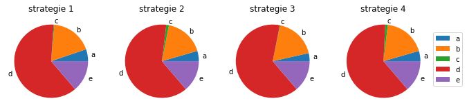

### Calculate and plot the TCO and CO2 emissions for a fleet of vehicles

We can calculate for a company the best 'transition strategy' for each vehicle they own and what the total emissions are for their entire fleet. Moreover, loading costs might be cheaper when vehicles can share a loading pole (N.B. Voeg dit toe).

List all vehicles of a company and put in a table.

```
Aantal voertuigen: 6
```

|  | type | leeftijd | gekoeld | Verwacht jaarkilometrage | Grijze/groene elektriciteit | max dagkilometrage | rijdt op (toekomstige) ZE zone | flexibel inzetbaar | technologische levensduur |
| --- | --- | --- | --- | --- | --- | --- | --- | --- | --- |
| 0 | Grote bakwagen (18t) | 6.0 | nee | 35000.0 | grijs | 200.0 | nee | nee | 7.0 |
| 2 | Grote bakwagen (18t) | 3.0 | nee | 50000.0 | grijs | 300.0 | nee | nee | 7.0 |
| 3 | Kleine bakwagen (12t) | 4.0 | nee | 30000.0 | groen | 150.0 | ja | nee | 10.0 |
| 4 | Trekker-oplegger | 1.0 | nee | 40000.0 | grijs | 140.0 | nee | nee | 7.0 |
| 5 | Kleine bakwagen (12t) | 2.0 | nee | 20000.0 | grijs | 600.0 | nee | nee | 8.0 |
| 6 | Grote bakwagen (18t) | 5.0 | nee | 45000.0 | groen | 300.0 | ja | nee | 7.0 |

Put the results in table format

|  | strategie | voertuig 1 | voertuig 2 | voertuig 3 | voertuig 4 | voertuig 5 | voertuig 6 |
| --- | --- | --- | --- | --- | --- | --- | --- |
| 0 | 1 | 135422.262013 | 138325.357313 | 119264.994193 | 164368.603133 | 132790.191487 | 140796.817900 |
| 1 | 2 | 132485.662767 | 139125.786967 | 124797.791707 | 164368.603133 | 132790.191487 | 170826.957067 |
| 2 | 3 | 133154.790667 | 147841.874840 | 149673.400913 | 164368.603133 | 132790.191487 | 259000.835960 |
| 3 | 4 | 137019.276447 | 142940.208807 | 134616.943100 | 163190.159600 | 132790.191487 | 207641.061407 |

Plot the average yearly tco costs until 2035 (or a different number of years) for each strategy in a bar plot. Also show how the emissions per strategy differ for wach strategy. N.B. Also draw a line with the expected savings on co2 emissions.

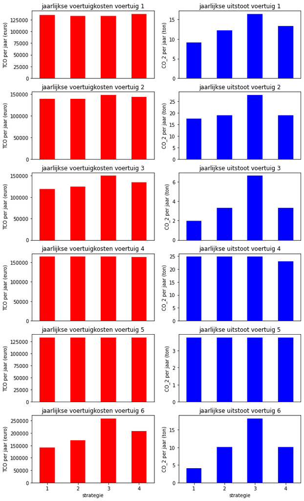

### Calculate loading capacity